# Diseño de instalaciones de agua industrial (1)

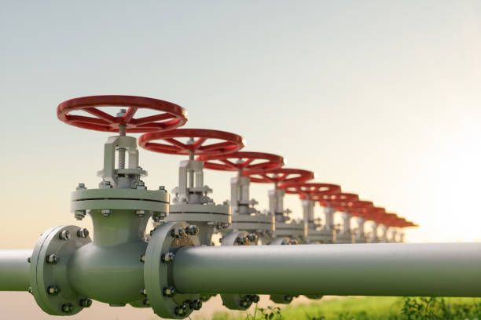

Fuente: istockphoto.com

### 1. Punto de partida

En el diseño de una instalación de agua no se comienza por los caños, sino por lo que consume agua. Se diseña desde el consumo de los equipos que se usan, por ejemplo un aspersor de riego puede consumir entre 6 y 15 litros por minuto. Es un dato que lo da el fabricante. Recordar que para el dimensionamiento el consumo se identifica con el caudal o gasto.

**Idea clave:** Analizar primero el consumo.

### 2. Diferencia con una instalación domiciliaria

**Domiciliaria:**

Se basa en consumos probables (ducha, cocina, etc.) ya que no es siempre igual. El dimensionamiento de los caños es más simple por que se usan tablas que vinculan la cantidad y tipo de artefactos directamente con el diámetro del caño. Los consumos probables son tenidas en cuenta para hacer la tabla pero luego no aparecen explícitamente en ella.

Además las instalaciones domiciliarias funcionan bien en un rango amplio de presiones, por ejemplo el rango para las duchas y griferías es de 1 a 3 bares aproximadamente.

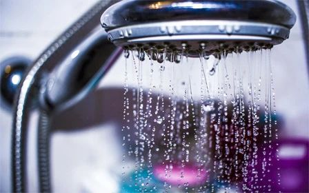

Fuente: caloryfrio.com

**Industrial:**

Aquí no se trata de estimar consumos probables sino que se recurre a datos del fabricante para saber que consumo específico tienen los equipos para que funcionen bien. Pueden ser instalaciones de riego, lavado, enfriamiento, etc.

Además en industria las exigencias suelen ser mayores:

- más caudal
- más control de presión (hay rangos más restringidos de presión)
- mayor complejidad

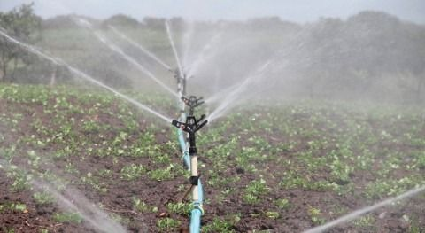

Fuente: iagua.es

### 3. Secuencia básica de diseño

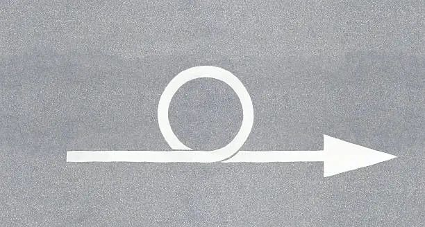

El diseño es iterativo. Fuente: unplash.com

Toda instalación sigue esta lógica:

1. Definir **qué consume agua**
2. Determinar el **caudal necesario**
3. Determinar la **presión requerida**
4. Diseñar la **red de cañerías**
5. Considerar **pérdidas de carga**
6. Seleccionar la **bomba**

El proceso es **iterativo**: se ajusta varias veces hasta que todo funcione correctamente.

### 4. Caudal y presión

Hay que considerarlos en conjunto, por ejemplo un aspersor de riego puede tener como requisito para su máximo rendimiento un determinado caudal y presión que suministra el fabricante.

- **Caudal:** cantidad de agua que circula (ej: m³/h, L/min)
- **Presión:** energía del agua para llegar hasta el lugar y que todo funcione correctamente (ej: bar, m.c.a.)

**Importante:** No se eligen al azar. Los define el **equipo o sistema**

### 5. Ejemplo: sistema de riego

Datos:

- 10 aspersores
- Cada uno consume: 0,6 m³/h
- Presión de trabajo: 2,5 bar

**Cálculo:**

Caudal total: $10 \cdot 0,6 = 6$ m³/h

Presión mínima en aspersores: 2,5 bar

La bomba deberá entregar: Ese caudal a una presión mayor (por pérdidas en cañerías)

**Idea final:** El diseño de una instalación consiste en adaptar la red (caños + bomba) a las necesidades del sistema.

### Cálculo básico del diámetro de cañerías

Partimos de:

$Q = v \cdot A$

Despejando el diámetro:

$D = \sqrt{\frac{4Q}{\pi v}}$

donde:

- (Q): caudal
- (v): velocidad del agua
- (D): diámetro del caño

Elegís una velocidad razonable → calculás el diámetro. Valores orientativos de velocidad: 0,5 a 2 m/s para instalaciones comunes. A más velocidad más pérdidas.